# Generalized Jeffreys’s Approximate Objective Bayes Factor

Part Six: Chi-Squared Test for Independence Simulation

============================================================================================================

Open Science Framework: https://osf.io/qeprj/

## 0. Getting Started

$\chi^2$-tests for

- goodness of fit: determine whether the data fits a specific distribution

```r
# Is the die fair?
rolls <- c(22, 23, 20, 25, 27, 33) # number of rolls for each face
chisq.test(rolls)
```

```
##
##  Chi-squared test for given probabilities
##
## data:  rolls
## X-squared = 4.24, df = 5, p-value = 0.5154
```

- **independence**: determine whether there is a significant association between two categorical variables

For each cell in the [contingency table](https://people.stat.sc.edu/hansont/stat705/categorical.pdf), calculate the expected frequency and, then, the test statistic as

$$\begin{align}
E_{ij}&=\frac{O_{i\centerdot}\cdot O_{\centerdot
j}}{N},\quad\text{where }N=\sum_{i=1}^R\sum_{j=1}^C O_{ij},\quad
O_{i\centerdot}=\sum_{j=1}^C O_{ij},\quad\text{and }O_{\centerdot
j}=\sum_{i=1}^R O_{ij} \\
\chi^2&=\sum_{i=1}^R\sum_{j=1}^C\frac{(O_{ij}-E_{ij})^2}{E_{ij}}\overset{\mathcal{H}_0}{\sim}\chi^2_{(R-1)(C-1)}
\end{align}$$

These calculations also apply to product multinomial sampling, where one variable’s marginals are fixed.

```r
# Does the seat belt make a difference? (Jobson, 1982, p. 18)
belt <- matrix(c(12813,  647,  359,  42,
                 65963, 4000, 2642, 303), nrow=2, byrow=T,
               dimnames=list(c("yesbelt", "nahbelt"), c("none", "minimal", "minor", "major")))
chisq.test(belt)
```

```
##
##  Pearson's Chi-squared test
##
## data:  belt
## X-squared = 59.224, df = 3, p-value = 8.61e-13
```

```r
# https://richarddmorey.github.io/BayesFactor/#ctables
BayesFactor::contingencyTableBF(belt, sampleType="jointMulti") # fixed total
```

```
## Bayes factor analysis
## --------------
## [1] Non-indep. (a=1) : 2186082 ±0%
##
## Against denominator:
##   Null, independence, a = 1
## ---
## Bayes factor type: BFcontingencyTable, joint multinomial
```

```r
BayesFactor::contingencyTableBF(belt, sampleType="indepMulti", fixedMargin="rows") # fixed row sums
```

```
## Bayes factor analysis
## --------------
## [1] Non-indep. (a=1) : 6455475 ±0%
##
## Against denominator:
##   Null, independence, a = 1
## ---
## Bayes factor type: BFcontingencyTable, independent multinomial
```

Assumption: Expected frequency in each cell $\geqslant5$

Warning Message

```r
mat <- matrix(c(12, 8, 11, 5, 5, 10, 16, 8, 15), nrow=3) # small cell sizes
chisq.test(mat) # WARNING
```

```
## Warning in chisq.test(mat): Chi-squared approximation may be incorrect
```

```
##
##  Pearson's Chi-squared test
##
## data:  mat
## X-squared = 1.899, df = 4, p-value = 0.7543
```

```r
chisq.test(mat, simulate.p.value=T)
```

```
##
##  Pearson's Chi-squared test with simulated p-value (based on 2000
##  replicates)
##
## data:  mat
## X-squared = 1.899, df = NA, p-value = 0.7711
```

```r
fisher.test(mat) # Fisher's exact test
```

```
##
##  Fisher's Exact Test for Count Data
##
## data:  mat
## p-value = 0.7517
## alternative hypothesis: two.sided
```

- homogeneity: determine whether different populations have the same distribution

scroll to top

## 1. Methods

### “*BayesFactor*” R Package

Gûnel and Dickey ([1974](https://doi.org/10.2307/2334738)) proposed the symmetric Dirichlet prior for the cell probabilities ($\sum_{k=1}^K\pi_k=1$) under the alternative hypothesis of association, noting that it is conjugate to the multinomial distribution.

$$\begin{equation} \tag{1}
(\pi_1,\dotsb,\pi_K)^\top\sim\operatorname{Dir}(a)=\frac{\Gamma(Ka)}{(\Gamma(a))^K}\prod_{k=1}^K\pi_k^{a-1}
\end{equation}$$

The key parameter is the shared concentration $a>0$.

- A (default) value of $a=1$ specifies a uniform prior over the $(K-1)$-simplex.
- Values $0<a<1$ lead to a prior that concentrates mass in the corners of the simplex (favoring extreme probabilities).
- Values $a>1$ lead to a prior that concentrates mass in the center of the simplex (favoring equal probabilities). $\pi_k=1/K$ as $a\to\infty$.

> Total Sum Fixed (Joint Multinomial)

$$\begin{equation} \tag{2}
(O_{11},\dotsb,O_{RC})^\top\mid
N,(\pi_{11},\dotsb,\pi_{RC})^\top\sim\operatorname{Multinomial}\left(N,(\pi_{11},\dotsb,\pi_{RC})^\top\right)
\end{equation}$$

$$\begin{equation} \tag{3}
\mathcal{H}_1:\
(\pi_{11},\dotsb,\pi_{RC})^\top\sim\operatorname{Dir}(a)
\end{equation}$$

$$\begin{align} \tag{4}
\text{versus}\quad\mathcal{H}_0:\
&(\pi_{1\centerdot},\dotsb,\pi_{R\centerdot})^\top\sim\operatorname{Dir}(Ca-C+1)
\\
&(\pi_{\centerdot 1},\dotsb,\pi_{\centerdot
C})^\top\sim\operatorname{Dir}(Ra-R+1) \\
&\pi_{ij}=\pi_{i\centerdot}\cdot\pi_{\centerdot j}
\end{align}$$

Under these priors, the conditional Bayes factor for independence given $N$ becomes a product/ratio of Dirichlet normalizing constants (beta functions) for the row and column margins versus the full $K$-dimensional Dirichlet (Good, [1950](https://doi.org/10.2307/2280518), p. 99).

> Row Sums Fixed (Independent Multinomial Rows)

For $i=1,\dotsb,R$,

$$\begin{equation} \tag{5}
(O_{i1},\dotsb,O_{iC})^\top\mid O_{i\centerdot},(w_{1\mid
i},\dotsb,w_{C\mid
i})^\top\sim\operatorname{Multinomial}(O_{i\centerdot},(w_{1\mid
i},\dotsb,w_{C\mid i})^\top)
\end{equation}$$

$$\begin{equation} \tag{6}
\mathcal{H}_1:\ (w_{1\mid i},\dotsb,w_{C\mid
i})^\top\overset{\text{i.i.d.}}{\sim}\operatorname{Dir}(a)
\end{equation}$$

$$\begin{align} \tag{7}
\text{versus}\quad\mathcal{H}_0:\ &(\pi_{\centerdot
1},\dotsb,\pi_{\centerdot C})^\top\sim\operatorname{Dir}(Ra-R+1) \\
&(w_{1\mid i},\dotsb,w_{C\mid i})^\top=(\pi_{\centerdot
1},\dotsb,\pi_{\centerdot C})^\top
\end{align}$$

Under these priors, the conditional Bayes factor for independence given the row totals reduces to a product/ratio of Dirichlet normalizing constants across rows versus the shared column vector (Good, [1950](https://doi.org/10.2307/2280518), p. 100).

scroll to top

### BIC Approximation

Approximating Bayes Factors from Bayesian Information Criterion (BIC)

The BIC for model $i$ with the number of free parameters $k_i$ and the sample size $N$ is $\text{BIC}(\mathcal{M}_i)=-2\ln{\mathcal{L}_i}+k_i\ln{N}\quad$ for $N\gg k_i$,

where $\mathcal{L}_i=p(\boldsymbol{y}\mid\hat{\boldsymbol{\theta}}_i,\mathcal{M}_i)$ is the maximum likelihood.

Use the second-order Taylor approximation of log-marginal likelihood of each model.

$$\begin{equation} \tag{8}
\mathit{BF}_{10}\approx\exp\left\{\frac{\text{BIC}(\mathcal{M}_0)-\text{BIC}(\mathcal{M}_1)}{2}\right\}
\end{equation}$$

Derivation in Wagenmakers ([2007](https://dx.doi.org/10.3758/BF03194105), Appendix B).

#### Assume a fixed total

The maximum likelihood estimates for the proportions are $\hat{\pi}_{ij}=O_{ij}\ /\ N$ under $\mathcal{H}_1$ and $\hat{\pi}_{ij}=O_{i\centerdot}\cdot O_{\centerdot j}\ /\ N^2$ under $\mathcal{H}_0$.

And the numbers of parameters are $k_1=R\cdot C-1$ under $\mathcal{H}_1$ and $k_0=R+C-2$ under $\mathcal{H}_0$, assuming a joint multinomial distribution.

```r
total <- sum(belt) # grand total
row_mar <- rowSums(belt) # row sums
col_mar <- colSums(belt) # column sums
expected <- outer(row_mar, col_mar) / total # outer product / grand total = expected frequency

# `prob` normalization is not necessary        ↓
logML_joint_H1 <- dmultinom(c(belt), total, c(belt), log=T) # log maximum likelihood under H₁
logML_joint_H0 <- dmultinom(c(belt), total, c(expected), log=T) # log maximum likelihood under H₀

BIC_joint_H1 <- -2 * logML_joint_H1 + (2*4-1) * log(total)
BIC_joint_H0 <- -2 * logML_joint_H0 + (2+4-2) * log(total)

exp((BIC_joint_H1 - BIC_joint_H0) / 2) # BF₀₁
```

```
## [1] 5.80304e-07
```

scroll to top

#### Assume fixed row sums

The maximum likelihood estimates for the proportions are $\hat{\pi}_{ij}=O_{ij}\ /\ O_{i\centerdot}$ under $\mathcal{H}_1$ and $\hat{\pi}_{ij}=O_{\centerdot j}\ /\ N$ under $\mathcal{H}_0$.

And the numbers of parameters are $k_1=R\cdot(C-1)$ under $\mathcal{H}_1$ and $k_0=C-1$ under $\mathcal{H}_0$, assuming independent multinomial distributions.

```r
logML_indep_H1 <- unname(dmultinom(belt[1,], row_mar[1], belt[1,], log=T) +
                         dmultinom(belt[2,], row_mar[2], belt[2,], log=T)) # log maximum likelihood under H₁
logML_indep_H0 <- unname(dmultinom(belt[1,], row_mar[1], col_mar, log=T) +
                         dmultinom(belt[2,], row_mar[2], col_mar, log=T)) # log maximum likelihood under H₀

BIC_indep_H1 <- -2 * logML_indep_H1 + (2*(4-1)) * log(total)
BIC_indep_H0 <- -2 * logML_indep_H0 + (4-1) * log(total)

exp((BIC_indep_H1 - BIC_indep_H0) / 2) # BF₀₁ (same)  <==
```

```
## [1] 5.80304e-07
```

scroll to top

### Approximate Bayes Factor

$$\begin{align}
\text{BIC}(\mathcal{M}_1)-\text{BIC}(\mathcal{M}_0)&=-2\ln{\mathcal{L}_1}+k_1\ln{N}+2\ln{\mathcal{L}_0}-k_0\ln{N}
\\
&=-2(\ln{\mathcal{L}_1}-\ln{\mathcal{L}_0})+(k_1-k_0)\ln{N} \\
&=-\Lambda+(k_1-k_0)\ln{N} \\
\\
\mathit{BF}_{01}&\approx\exp\left\{\frac{\text{BIC}(\mathcal{M}_1)-\text{BIC}(\mathcal{M}_0)}{2}\right\}
\\
&=\exp\left\{\frac{-\Lambda+(k_1-k_0)\ln{N}}{2}\right\} \\
&=N^{\frac{(R-1)(C-1)}{2}}\!\cdot\exp\left\{-\frac{\Lambda}{2}\right\}
\tag{$8^\prime$}
\end{align}$$

Test on a Single Parameter

The test statistic in a Wald test is $W=\left(\frac{\hat{\theta}-\theta_0}{\text{se}(\hat{\theta})}\right)^2\sim\chi_1^2$ under $\mathcal{H}_0$, where $\hat{\theta}$ is the maximum likelihood estimate, and $\text{se}(\hat{\theta})$ is the standard error.

Wagenmakers ([2022](https://doi.org/10.31234/osf.io/egydq); its Eq. 6) reviewed the Jeffreys-style approximate Bayes factor (JAB) and proposed a piecewise approximation (WAB) from $p$-value and effective sample size $N$ in Eq. 10.

The complication with JAB is that the approximation is valid **only** when $\text{se}(\hat{\theta})\ll\sigma_g$, where $\sigma_g$ is the scale of the prior distribution $g(\theta)$. Note that with very small sample sizes, this assumption is not true and Eq. 9 is biased against $\mathcal{H}_0$.

$$\begin{equation} \tag{9}
\textit{JAB}_{01}=A\cdot\sqrt{N}\exp\left\{-\frac{1}{2}W\right\}
\end{equation}$$

A normal unit-information prior for $\theta$ yields $A=1$. Based on the Jeffreys prior, the general approximation specifies $A=\sqrt{\pi/2}\approx1.253$.

Wagenmakers’s piecewise approximation is

$$\textit{WAB}_{01}\approx
\begin{cases} \tag{10}
\text{$\ p^{\frac{1}{4}}\sqrt{N}$,} & \text{$p>0.5$} \\
\\
\text{$\ \sqrt{pN}$,} & \text{$0.1<p\leqslant0.5$ (simpler)} \\
\\
\text{$\ \frac{4}{3}p^{\frac{2}{3}}\sqrt{N}$,} &
\text{$0.1<p\leqslant0.5$ (more precise)} \\
\\
\text{$\ 3p\sqrt{N}$,} & \text{$p\leqslant0.1$}
\end{cases}$$

Wagenmakers ([2022](https://doi.org/10.31234/osf.io/egydq), p. 28-30) demonstrated how to compare two proportions in a $2\times2$ contingency table (odds ratio representation).

scroll to top

### Extended JAB

We have encountered an issue with BIC approximation-based methods in chi-squared tests for independence.

Consider a scenario where the total number of observations is 200, and the contingency table is $3\times4$. A $p$-value of 0.01 corresponds to an original $\mathit{JAB}_{01}$ value of 1865 in favor of the null hypothesis, while a $p$-value of 0.0001 corresponds to an original $\mathit{JAB}_{01}$ value of 7.66, also in favor of the null. These results seem paradoxical.

```r
pVal <- .0001; N <- 200; R <- 3; C <- 4; df <- (R-1) * (C-1)

N^(df/2) * exp(-0.5 * qchisq(1-pVal, df) * (N-1) / N) # original JAB₀₁
```

```
## [1] 7.663144
```

```r
sqrt(N) * exp(-0.5 * qchisq(1-pVal, df) * (N^(1/df)-1) / N^(1/df)) # extended JAB₀₁
```

```
## [1] 0.004008032
```

$\mathcal{H}_0:\boldsymbol{\theta}=\boldsymbol{\theta}_0$ versus $\mathcal{H}_1:\boldsymbol{\theta}\neq\boldsymbol{\theta}_0$

To reduce the extreme bias towards the null hypothesis, we assume the prior $\boldsymbol{\theta}\sim\boldsymbol{\mathcal{N}}_q\!\left(\hat{\boldsymbol{\theta}},\ N^{1/q}\cdot I^{-1}(\hat{\boldsymbol{\theta}})\right)$, which, for $q=1$, corresponds to the normal unit-information prior. For $q>1$, the prior becomes more informative, placing more weight on the maximum likelihood estimate.

scroll to top

### Test-Based Bayes Factor

Bayes Factors Based on the Sampling Distributions of Test Statistics

Johnson ([2005](https://doi.org/10.1111/j.1467-9868.2005.00521.x)) developed an approach to computing Bayes factors based on test statistics. These Bayes factors are derived by modeling the test statistic and considering its distribution under both the null and alternative hypotheses. The resulting Bayes factor is an approximation of a full Bayes factor. Additionally, priors for the parameter under test are chosen to maximize the marginal density of the data (the test statistic in this context) under the alternative hypothesis, thereby making the test statistic Bayes factor (TSBF) an upper bound on the weight of evidence against the null hypothesis.

Unlike JAB/WAB, the proposed TSBFs are also unable to find evidence in favor of the null hypothesis. That is to say, the range of these measures of evidence is $1\leqslant\textit{BF}_{10}<\infty$.

- Dirichlet prior https://github.com/zhengxiaoUVic/Bayesian
- TSBFs provide the least conservative measure of evidence against the null hypothesis, yielding relatively larger values of $\mathit{TSBF}_{10}$.
- TSBFs may lack the property of **coherence** ($\textit{BF}_{12}=\textit{BF}_{10}\cdot\textit{BF}_{02}$) due to the different transformations applied to the data.

#### TSBFs for goodness of fit

$$\mathit{TSBF}_{10}=
\begin{cases}\ \tag{14a}
\left(\frac{K-1}{\chi^2}\right)^{\frac{K-1}{2}}\!\cdot\exp\left\{\frac{\chi^2-K+1}{2}\right\},
& \text{if } \chi^2 > K-1 \\ \\ \ 1, &
\text{otherwise}\end{cases}$$

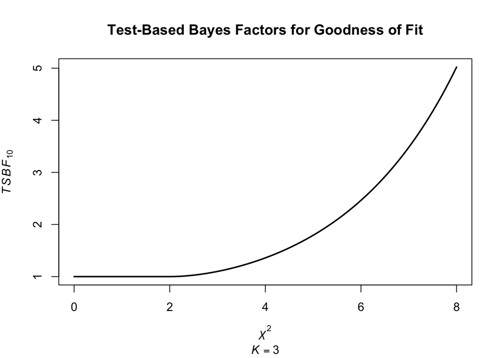

```r
TSBF10a <- function(K, chisq) {
  #' Input -
  #' K:       number of mutually exclusive events (integer)
  #' chisq:   chi-squared test statistic
  #' Output - test-based Bayes factor in favor of the alternative

  ifelse(chisq > K-1,
         ((K-1) / chisq)^((K-1)/2) * exp((chisq-K+1)/2),
         1) # TSBF₁₀ (Johnson, 2005, p. 693)
}
curve(TSBF10a(K=3, x), xlab=expression(italic(χ)^2), ylab=expression(italic(TSBF)[10]),
      main="Test-Based Bayes Factors for Goodness of Fit", from=0, to=8, lwd=2,
      sub=bquote(italic(K)==3))
```

scroll to top

#### TSBFs for independence

$$\mathit{TSBF}_{10}=
\begin{cases}\ \tag{14b}
\left(\frac{(R-1)(C-1)}{\chi^2}\right)^{\frac{(R-1)(C-1)}{2}}\!\cdot\exp\left\{\frac{\chi^2-(R-1)(C-1)}{2}\right\},
& \text{if } \chi^2 > (R-1)(C-1) \\ \\ \ 1, &
\text{otherwise}\end{cases}$$

Assume two factors with $R$ and $C$ levels, respectively. The data are organized in an $R\times C$ table, representing the number of sampled units falling into each category of the row and column factors.

The null hypothesis is that the two factors are independent. In other words, the occurrence of one factor does not affect the occurrence of the other. $\mathcal{H}_0:\pi_{ij}=\pi_{i\centerdot}\cdot\pi_{\centerdot j}$

The alternative hypothesis is that the two factors are not independent. This means there is some association between the two factors.

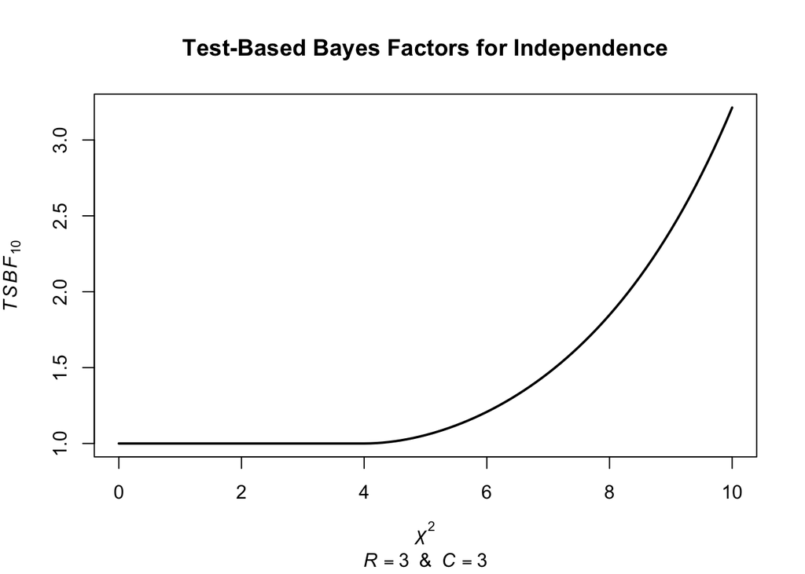

```r
TSBF10b <- function(R, C, chisq) {
  #' Input -
  #' R:       number of levels in the row factor
  #' C:       number of levels in the column factor
  #' chisq:   chi-squared test statistic
  #' Output - test-based Bayes factor in favor of the alternative

  ifelse(chisq > (R-1)*(C-1),
         ((R-1)*(C-1) / chisq)^((R-1)*(C-1)/2) * exp((chisq-(R-1)*(C-1))/2),
         1) # TSBF₁₀ (Johnson, 2005, p. 694)
}
curve(TSBF10b(R=3, C=3, x), xlab=expression(italic(χ)^2), ylab=expression(italic(TSBF)[10]),
      main="Test-Based Bayes Factors for Independence", from=0, to=10, lwd=2,
      sub=bquote(italic(R)==3~~"&"~~italic(C)==3))
```

scroll to top

### Log-Linear Model

#### GLM

We can fit a generalized linear model (GLM) on contingency table data using the Poisson family (and the log link). This approach treats the counts in the contingency table as the response variable and models them as Poisson-distributed. A Poisson regression model is sometimes referred to as a log-linear model, particularly when used to model contingency tables.

We test for independence by comparing full (saturated) and null (independence) models.

$$\begin{align}
O_{ij}&\overset{\text{ind.}}{\sim}\operatorname{Pois}(\mu_{ij}) \\
\mathcal{M}_1:\
\ln{\mu_{ij}}&=\mu+\alpha_i+\beta_j+(\alpha\beta)_{ij} \\
\text{versus}\quad\mathcal{M}_0:\
\ln{\mu_{ij}}&=\mu+\alpha_i+\beta_j\qquad\text{for}\ i=1,\dotsb,R\
\text{and}\ j=1,\dotsb,C
\end{align}$$

```r
belt_long <- data.frame("fasten"=rep(c("yesbelt", "nahbelt"), 4),
                        "injure"=rep(c("none", "minimal", "minor", "major"), each=2),
                        # "count"=c(12813, 65963, 647, 4000, 359, 2642, 42, 303), # (Jobson, 1982, p. 18)
                        "count"=c(100, 100, 100, 100, 100, 100, 100, 100),
                        stringsAsFactors=T) # long format

#                   ↓ row    ↓ column
fit1 <- glm(count ~ fasten * injure, belt_long, family=poisson(link="log")) # full model fit
fit0 <- glm(count ~ fasten + injure, belt_long, family=poisson(link="log")) # null model fit

anova(fit0, fit1, test="Chisq") # likelihood ratio test
```

```
## Analysis of Deviance Table
##
## Model 1: count ~ fasten + injure
## Model 2: count ~ fasten * injure
##   Resid. Df Resid. Dev Df   Deviance Pr(>Chi)
## 1         3 4.2633e-14
## 2         0 2.1316e-14  3 2.1316e-14        1
```

```r
pchisq(fit0$deviance, fit0$df.residual, lower.tail=F) # examining the deviance of the null model
```

```
## [1] 1
```

```r
summary(fit1)
```

```
##
## Call:
## glm(formula = count ~ fasten * injure, family = poisson(link = "log"),
##     data = belt_long)
##
## Coefficients:
##                               Estimate Std. Error z value Pr(>|z|)
## (Intercept)                  4.605e+00  1.000e-01   46.05   <2e-16 ***
## fastenyesbelt               -1.848e-31  1.414e-01    0.00        1
## injureminimal               -4.936e-31  1.414e-01    0.00        1
## injureminor                 -1.627e-31  1.414e-01    0.00        1
## injurenone                  -8.248e-31  1.414e-01    0.00        1
## fastenyesbelt:injureminimal  5.719e-32  2.000e-01    0.00        1
## fastenyesbelt:injureminor    1.381e-31  2.000e-01    0.00        1
## fastenyesbelt:injurenone    -3.001e-15  2.000e-01    0.00        1
## ---
## Signif. codes:  0 '***' 0.001 '**' 0.01 '*' 0.05 '.' 0.1 ' ' 1
##
## (Dispersion parameter for poisson family taken to be 1)
##
##     Null deviance: 0.0000e+00  on 7  degrees of freedom
## Residual deviance: 2.1316e-14  on 0  degrees of freedom
## AIC: 67.558
##
## Number of Fisher Scoring iterations: 2
```

```r
summary(fit0)
```

```
##
## Call:
## glm(formula = count ~ fasten + injure, family = poisson(link = "log"),
##     data = belt_long)
##
## Coefficients:
##                 Estimate Std. Error z value Pr(>|z|)
## (Intercept)    4.605e+00  7.906e-02   58.25   <2e-16 ***
## fastenyesbelt -8.629e-17  7.071e-02    0.00        1
## injureminimal  1.487e-31  1.000e-01    0.00        1
## injureminor    4.840e-32  1.000e-01    0.00        1
## injurenone    -9.207e-16  1.000e-01    0.00        1
## ---
## Signif. codes:  0 '***' 0.001 '**' 0.01 '*' 0.05 '.' 0.1 ' ' 1
##
## (Dispersion parameter for poisson family taken to be 1)
##
##     Null deviance: 0.0000e+00  on 7  degrees of freedom
## Residual deviance: 4.2633e-14  on 3  degrees of freedom
## AIC: 61.558
##
## Number of Fisher Scoring iterations: 2
```

- Both approaches assume that the Poisson model is appropriate for the data (equidispersion, i.e., variance equals the mean).
- If the data exhibit overdispersion (variance greater than the mean), consider using a quasi-Poisson or negative binomial model.
- If the data exhibit underdispersion (variance less than the mean), a binomial model may be more suitable.

scroll to top

#### Dummy Variables

Both the row and column factors are categorical, so the regression model uses dummy variables. In this example `belt_long`, the row factor $A$ has two levels, while the column factor $B$ has four levels.

$$\begin{align}
\ln{\mu_{ij}}=b_0& \\
+b_1&\cdot D_{A_2} \\
+b_2&\cdot D_{B_2}+b_3\cdot D_{B_3}+b_4\cdot D_{B_4} \\
+b_5&\cdot D_{A_2B_2}+b_6\cdot D_{A_2B_3}+b_7\cdot D_{A_2B_4}
\end{align}$$

- $b_0$ is the intercept (when both factors are at their reference levels $A_1$ and $B_1$).
- $b_1$ is the effect of being at level $A_2$ (relative to $A_1$), adjusting for the column factor.
- $b_2$ is the effect of being at level $B_2$ (relative to $B_1$), adjusting for the row factor.
- …
- $b_5$ is the effect of the interaction between $A_2$ and $B_2$.
- …

Thus, the test-relevant parameters are $\boldsymbol{\theta}=(b_5,\ b_6,\ b_7)^\top$.

The table below enumerates $\ln{\mu_{ij}}$ for each factor-level combination.

|  |  | $B_1$ | $B_2$ | $B_3$ | $B_4$ |
| --- | --- | --- | --- | --- | --- |
| $A_1$ |  | $\mu+\alpha_1+\beta_1+(\alpha\beta)_{11}$ $=$ $b_0$ | $\mu+\alpha_1+\beta_2+(\alpha\beta)_{12}$ $=$ $b_0+b_2$ | $\mu+\alpha_1+\beta_3+(\alpha\beta)_{13}$ $=$ $b_0+b_3$ | $\mu+\alpha_1+\beta_4+(\alpha\beta)_{14}$ $=$ $b_0+b_4$ |
| $A_2$ |  | $\mu+\alpha_2+\beta_1+(\alpha\beta)_{21}$ $=$ $b_0+b_1$ | $\mu+\alpha_2+\beta_2+(\alpha\beta)_{22}$ $=$ $b_0+b_1+b_2+b_5$ | $\mu+\alpha_2+\beta_3+(\alpha\beta)_{23}$ $=$ $b_0+b_1+b_3+b_6$ | $\mu+\alpha_2+\beta_4+(\alpha\beta)_{24}$ $=$ $b_0+b_1+b_4+b_7$ |

```r
R <- 2; C <- 4
mat <- matrix(0, nrow=R*C, ncol=R*C); i <- 1; j <- 0
for (c in 1:C) {
  for (r in 1:R) {
    if(r > 1) mat[i, r] <- 1
    if(c > 1) mat[i, R+c-1] <- 1
    if(r > 1 & c > 1) {
      mat[i, R+C+j] <- 1
      j <- j + 1
    }
    i <- i + 1
  }
}
mat[, 1] <- 1 # design matrix
```

$$(\ln{\mu_{11}},\ \ln{\mu_{21}},\ \ln{\mu_{12}},\ \ln{\mu_{22}},\
\ln{\mu_{13}},\ \ln{\mu_{23}},\ \ln{\mu_{14}},\ \ln{\mu_{24}})^\top=
\begin{pmatrix}
1 & 0 & 0 & 0 & 0 & 0 & 0 & 0 \\
1 & 1 & 0 & 0 & 0 & 0 & 0 & 0 \\
1 & 0 & 1 & 0 & 0 & 0 & 0 & 0 \\
1 & 1 & 1 & 0 & 0 & 1 & 0 & 0 \\
1 & 0 & 0 & 1 & 0 & 0 & 0 & 0 \\
1 & 1 & 0 & 1 & 0 & 0 & 1 & 0 \\
1 & 0 & 0 & 0 & 1 & 0 & 0 & 0 \\
1 & 1 & 0 & 0 & 1 & 0 & 0 & 1
\end{pmatrix}
\cdot(b_0,\ b_1,\ b_2,\ b_3,\ b_4,\ b_5,\ b_6,\ b_7)^\top$$

scroll to top

#### Stan

**Note**: In Poisson regression, the sample size corresponds to the number of cells $K=R\times C$.

```r
stancode6M <- "
data {
  int<lower=4> K;                       // number of cells, R * C
  int<lower=0> Y[K];                    // observed counts by column
  int<lower=1> S;                       // number of parameters (size of coefficient vector)
  matrix[K,S] X;                        // design matrix for the log-linear model
  vector[S] mu;                         // mean vector for the multivariate normal prior
  matrix[S,S] Sigma;                    // covariance matrix for the multivariate normal prior
}

parameters {
  vector[S] b;                          // coefficient vector for the log-linear model
}

model {
  // Prior on coefficients
  target += multi_normal_lpdf(b | mu, Sigma);

  // Likelihood (Poisson model with log-linear mean)
  target += poisson_lpmf(Y | exp(X * b));
}"

stanmodel6M <- stan_model(model_code=stancode6M)

datalist1 <- list(K=R*C, Y=belt_long$count, S=R*C, X=mat,
                  mu=coef(fit1), # MLE for the coefficients
                  Sigma=vcov(fit1) * (R*C)^(1/((R-1)*(C-1))))
                        # inverse of the observed Fisher information × number of cells

stanfitM1 <- sampling(stanmodel6M, data=datalist1,
                      iter=15000, warmup=5000, chains=3, seed=277, refresh=0)

rstan::summary(stanfitM1)[[1]] %>% kable(digits=4) %>% kable_classic(full_width=F)
```

|  | mean | se_mean | sd | 2.5% | 25% | 50% | 75% | 97.5% | n_eff | Rhat |
| --- | --- | --- | --- | --- | --- | --- | --- | --- | --- | --- |
| b[1] | 4.6045 | 0.0009 | 0.0815 | 4.4424 | 4.5498 | 4.6050 | 4.6595 | 4.7643 | 8481.021 | 1.0001 |
| b[2] | -0.0016 | 0.0012 | 0.1154 | -0.2273 | -0.0789 | -0.0020 | 0.0757 | 0.2270 | 8645.935 | 1.0000 |
| b[3] | -0.0022 | 0.0011 | 0.1156 | -0.2295 | -0.0799 | -0.0014 | 0.0761 | 0.2247 | 10881.324 | 1.0001 |
| b[4] | -0.0018 | 0.0011 | 0.1152 | -0.2265 | -0.0805 | -0.0008 | 0.0765 | 0.2244 | 10147.156 | 1.0000 |
| b[5] | -0.0017 | 0.0011 | 0.1161 | -0.2314 | -0.0791 | -0.0009 | 0.0765 | 0.2266 | 10342.893 | 1.0000 |
| b[6] | 0.0023 | 0.0016 | 0.1635 | -0.3173 | -0.1083 | 0.0031 | 0.1126 | 0.3203 | 10733.894 | 1.0000 |
| b[7] | 0.0015 | 0.0016 | 0.1625 | -0.3159 | -0.1083 | 0.0028 | 0.1112 | 0.3162 | 10316.407 | 1.0000 |
| b[8] | 0.0018 | 0.0016 | 0.1638 | -0.3223 | -0.1081 | 0.0019 | 0.1118 | 0.3236 | 10494.821 | 1.0001 |
| lp__ | -21.5045 | 0.0188 | 2.0185 | -26.2650 | -22.6331 | -21.1723 | -20.0312 | -18.5715 | 11511.420 | 1.0002 |

```r
datalist0 <- list(K=R*C, Y=belt_long$count, S=R+C-1, X=mat[, 1:(R+C-1)],
                  mu=coef(fit0),
                  Sigma=vcov(fit0) * (R*C)^(1/((R-1)*(C-1))))

stanfitM0 <- sampling(stanmodel6M, data=datalist0,
                      iter=15000, warmup=5000, chains=3, seed=277, refresh=0)

rstan::summary(stanfitM0)[[1]] %>% kable(digits=4) %>% kable_classic(full_width=F)
```

|  | mean | se_mean | sd | 2.5% | 25% | 50% | 75% | 97.5% | n_eff | Rhat |
| --- | --- | --- | --- | --- | --- | --- | --- | --- | --- | --- |
| b[1] | 4.6039 | 0.0006 | 0.0645 | 4.4759 | 4.5609 | 4.6040 | 4.6478 | 4.7296 | 12297.48 | 1.0002 |
| b[2] | 0.0000 | 0.0004 | 0.0580 | -0.1139 | -0.0394 | 0.0002 | 0.0393 | 0.1132 | 17924.18 | 1.0002 |
| b[3] | -0.0002 | 0.0007 | 0.0817 | -0.1611 | -0.0552 | 0.0000 | 0.0543 | 0.1596 | 14973.87 | 1.0001 |
| b[4] | -0.0002 | 0.0007 | 0.0812 | -0.1584 | -0.0559 | -0.0001 | 0.0542 | 0.1585 | 14906.61 | 1.0001 |
| b[5] | -0.0004 | 0.0007 | 0.0813 | -0.1602 | -0.0547 | -0.0003 | 0.0540 | 0.1590 | 14682.10 | 1.0000 |
| lp__ | -21.3608 | 0.0140 | 1.5743 | -25.2353 | -22.1841 | -21.0439 | -20.1993 | -19.2832 | 12720.81 | 1.0000 |

Note that to compute the (log) marginal likelihood for a Stan model, we need to specify the model in a certain way. Instead of using “~” signs for specifying distributions, we need to directly use the (log) density functions. The reason for this is that when using the “~” sign, constant terms are dropped which are not needed for sampling from the posterior. However, for computing the marginal likelihood, these constants need to be retained. For instance, instead of writing `y ~ normal(mu, sigma);` we would need to write `target += normal_lpdf(y | mu, sigma);` ([Gronau, 2021](https://cran.r-project.org/web/packages/bridgesampling/vignettes/bridgesampling_stan_ttest.html)).

scroll to top

#### Savage–Dickey Density Ratio

**The Savage–Dickey density ratio** is a special form of the Bayes factor for **nested** models by dividing the value of  
the posterior density over the parameters for the alternative model evaluated at the hypothesized value by  
the prior for the same model evaluated at the same point.

$$\begin{equation} \tag{11}
\textit{BF}_{01}:=\frac{p(\boldsymbol{y}\mid
\mathcal{M}_0)}{p(\boldsymbol{y}\mid
\mathcal{M}_1)}=\frac{\color{#0055A4}{p(\boldsymbol{\theta}=\boldsymbol{\theta}_0\mid\boldsymbol{y},\mathcal{M}_1)}}{\color{#EF4135}{p(\boldsymbol{\theta}=\boldsymbol{\theta}_0\mid
\mathcal{M}_1)}}
\end{equation}$$

```r
thetaS <- extract(stanfitM1, pars="b")$b[,-c(1:(R+C-1))] # posterior samples
dPost <- predict(ks::kde(thetaS), x=rep(0, (R-1)*(C-1))) # estimated posterior density
dPrior <- mvtnorm::dmvnorm(rep(0, (R-1)*(C-1)),
                           datalist1$mu[-c(1:(R+C-1))],
                           datalist1$Sigma[-c(1:(R+C-1)),-c(1:(R+C-1))])
c("Numerator"=dPost, "Denominator"=dPrior, "BF₀₁"=dPost / dPrior) # Savage–Dickey density ratio
```

```
##   Numerator Denominator        BF₀₁
##   17.610813    3.968355    4.437812
```

scroll to top

#### Bridge Sampling

**Bridge Sampling** `devtools::install_github("quentingronau/bridgesampling@master")`

All terms are conditional on $\mathcal{M}_i$.

$$\begin{align} \tag{12}
\color{#EE1C25}{p(\boldsymbol{y})}=&\frac{\mathbb{E}_{g(\boldsymbol{\theta})}[\hspace{0.1em}p(\boldsymbol{y}\mid\boldsymbol{\theta})\cdot
p(\boldsymbol{\theta})\cdot
h(\boldsymbol{\theta})]}{\mathbb{E}_\text{post}[\hspace{0.1em}g(\boldsymbol{\theta})\cdot
h(\boldsymbol{\theta})]} \\
\\
\approx&\frac{\frac{1}{N_2}\sum_{r=1}^{N_2}p(\boldsymbol{y}\mid\boldsymbol{\theta}_r^{\text{prop}})\cdot
p(\boldsymbol{\theta}_r^{\text{prop}})\cdot
h(\boldsymbol{\theta}_r^{\text{prop}})}{\frac{1}{N_1}\sum_{s=1}^{N_1}g(\boldsymbol{\theta}_s^\text{post})\cdot
h(\boldsymbol{\theta}_s^\text{post})}, \\
\\
&\hspace{15em}\boldsymbol{\theta}_r^{\text{prop}}\sim
g(\boldsymbol{\theta}), \\
&\hspace{15em}\boldsymbol{\theta}_s^\text{post}\sim
p(\boldsymbol{\theta}\mid\boldsymbol{y}),
\end{align}$$

where $g(\boldsymbol{\theta})$ is the proposal distribution

and $h(\boldsymbol{\theta})$ is the bridge function, $h(\boldsymbol{\theta})=\frac{C}{s_1\cdot p(\boldsymbol{y}\mid\boldsymbol{\theta})\cdot p(\boldsymbol{\theta})+s_2\cdot \color{#EE1C25}{p(\boldsymbol{y})}\cdot g(\boldsymbol{\theta})}$ and $s_j=\frac{N_j}{N_1+N_2}$ for $j\in\{1,2\}$.

```r
M1 <- bridge_sampler(stanfitM1, silent=T)
M0 <- bridge_sampler(stanfitM0, silent=T)
bf(M0, M1) # BF₀₁ via bridge sampling, exp(M0$logml - M1$logml)
```

```
## Estimated Bayes factor in favor of M0 over M1: 5.18886
```

```r
summary(M1)
```

```
##
## Bridge sampling log marginal likelihood estimate
## (method = "normal", repetitions = 1):
##
##  -30.17188
##
## Error Measures:
##
##  Relative Mean-Squared Error: 1.421934e-07
##  Coefficient of Variation: 0.0003770854
##  Percentage Error: 0%
##
## Note:
## All error measures are approximate.
```

```r
summary(M0)
```

```
##
## Bridge sampling log marginal likelihood estimate
## (method = "normal", repetitions = 1):
##
##  -28.52536
##
## Error Measures:
##
##  Relative Mean-Squared Error: 3.087146e-08
##  Coefficient of Variation: 0.0001757028
##  Percentage Error: 0%
##
## Note:
## All error measures are approximate.
```

scroll to top

#### Monte Carlo Error

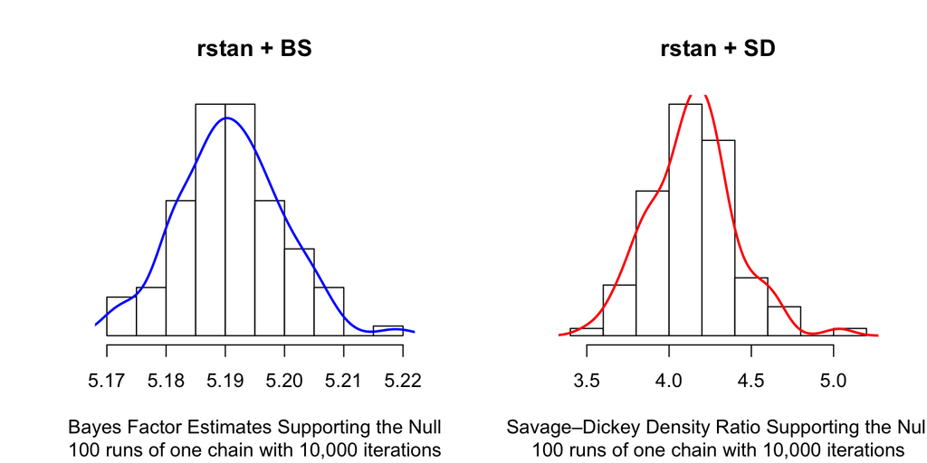

```r
BFBS <- function(seed=277, diagnostics=F) {
  stanfitM0 <- sampling(stanmodel6M, data=datalist0,
                        iter=15000, warmup=5000, chains=1, seed=seed, refresh=0)

  stanfitM1 <- sampling(stanmodel6M, data=datalist1,
                        iter=15000, warmup=5000, chains=1, seed=seed, refresh=0)

  thetaS <- extract(stanfitM1, pars="b")$b[,-c(1:(R+C-1))] # posterior samples
  dPost <- predict(ks::kde(thetaS), x=rep(0, (R-1)*(C-1))) # estimated posterior density
  dPrior <- mvtnorm::dmvnorm(rep(0, (R-1)*(C-1)),
                             datalist1$mu[-c(1:(R+C-1))],
                             datalist1$Sigma[-c(1:(R+C-1)),-c(1:(R+C-1))])
  SDdr <- dPost / dPrior # Savage–Dickey density ratio (BF₀₁)

  set.seed(seed)
  M0 <- bridge_sampler(stanfitM0, silent=T)

  set.seed(seed)
  M1 <- bridge_sampler(stanfitM1, silent=T)

  if (diagnostics) {
    list("bf"=exp(M0$logml - M1$logml),
         "pererr.M1"=error_measures(M1)$cv,
         "pererr.M0"=error_measures(M0)$cv,
         "stan.M1"=stanfitM1, "stan.M0"=stanfitM0,
         "savage.dickey"=SD)
  } else {
    list("bf"=exp(M0$logml - M1$logml),
         "pererr.M1"=error_measures(M1)$cv,
         "pererr.M0"=error_measures(M0)$cv,
         "savage.dickey"=SDdr)
  }
}

num <- 100; BF <- PerErr.M1 <- PerErr.M0 <- SDdr <- numeric(num)
system.time(
for (i in 1:num) { # roughly 411 seconds of run time
  result <- BFBS(seed=i)
  BF[i] <- result$bf
  PerErr.M1[i] <- result$pererr.M1
  PerErr.M0[i] <- result$pererr.M0
  SDdr[i] <- result$savage.dickey
})

# range(PerErr.M1); range(PerErr.M0)

par(mfrow=c(1,2))
hist(BF, prob=T, col="white", yaxt="n", ylab="", main="rstan + BS",
     sub="100 runs of one chain with 10,000 iterations",
     xlab="Bayes Factor Estimates Supporting the Null") # BF₀₁: rstan + BS
lines(density(BF), col="blue", lwd=2)
hist(SDdr, prob=T, col="white", yaxt="n", ylab="", main="rstan + SD",
     sub="100 runs of one chain with 10,000 iterations",
     xlab="Savage–Dickey Density Ratio Supporting the Null") # BF₀₁: rstan + SD
lines(density(SDdr), col="red", lwd=2)
```

scroll to top

### Non-Centrality Parameter

The distribution of the chi-squared statistic under the alternative hypothesis follows a non-central chi-squared distribution. The non-centrality parameter can be consistently estimated using the chi-squared statistic itself.

```r
cat("chisq =",  qchisq(1-0.05, df=4), " <  chisq_ncp =", qchisq(1-0.05, df=4, ncp=qchisq(1-0.05, df=4)))
```

```
## chisq = 9.487729  <  chisq_ncp = 26.03659
```

In the expression for eJAB, what would happen if we replaced the chi-squared quantile function with the quantile function of the non-central chi-squared distribution, using the non-centrality parameter estimated by the chi-squared statistic? Would this provide a more accurate eJAB for chi-squared tests?

## 2. Simulation

Experimental Design

When simulating a contingency table, understanding the context of the [experimental design](https://www.graphpad.com/guides/prism/latest/statistics/stat_simulating_a_contingency_table.htm) is crucial because it determines how the data are generated and interpreted. Consider two factors: *exposure* (e.g., smoking or not) and *outcome* (e.g., lung cancer or not).

`rmultinom(n, size, prob)`

- Cross-Sectional: Both factor are measured simultaneously.  
  The **total** sample size is fixed. Draw subjects with certain probabilities of having each combination of exposure and outcome.  
  Check the `sampleType="jointMulti"` argument in `?BayesFactor::contingencyTableBF`
- Prospective: Start with a cohort of subjects classified by their exposure status. Then, follow over time to see who develops the outcome.
- Experimental: Assign subjects to different interventions (rows) and then measure the outcome. Clinical trial.  
  Fix **row** totals (exposure groups) and simulate the outcomes (columns).  
  Check the `sampleType="indepMulti"` and `fixedMargin="rows"` arguments in `?BayesFactor::contingencyTableBF`
- Retrospective: Start by selecting subjects based on the outcome. The rows represent exposure status, and the columns represent the case/control status. Look back in time to determine exposure.  
  First fix the **column** totals (cases and controls) and then simulate the distribution of exposure (rows) within these groups.

[Further reading](https://www.ma.imperial.ac.uk/~das01/MyWeb/M3S12/Handouts/Notes/Chap6.pdf): The equivalence between Poisson and multinomial sampling models for contingency tables.

Effect Size

One measure of effect size for $\chi^2$-tests is Cohen’s omega, $\omega=\sqrt{\sum_{i=1}^R\sum_{j=1}^C\frac{(\pi_{1ij}-\pi_{0ij})^2}{\pi_{0ij}}}$,  
where $\pi_{0ij}$ and $\pi_{1ij}$ are the proportions of the $(i,j)$ cell in an $R\times C$ contingency table under $\mathcal{H}_0$ and $\mathcal{H}_1$, respectively.

- Cohen ([1988](https://doi.org/10.4324/9780203771587), p. 224-226) suggests that the effect sizes are *generally* small, medium, and large for $\omega\in\{0.1,\ 0.3,\ 0.5\}$, respectively.

We consider the uniform proportion $\pi_{0ij}=\frac{1}{RC}$ under $\mathcal{H}_0$.

Under $\mathcal{H}_1$, we set the proportion $p_{1ij}=\frac{1}{RC}+(-1)^{i+j}\cdot\delta\cdot(1-\boldsymbol{1}_{i=R,\ R\mod2=1})\cdot(1-\boldsymbol{1}_{j=C,\ C\mod2=1})$ for $i\leqslant R$ and $j\leqslant C$.

Thus, Cohen’s $\omega=2\delta\sqrt{RC\left\lfloor\frac{R}{2}\right\rfloor\left\lfloor\frac{C}{2}\right\rfloor}$.

Design (Note that each row may not have been normalized if `sampleType="indepMulti"`.)

| $\mathcal{H}_1$ | $\frac{1}{RC}+\delta$ | $\frac{1}{RC}-\delta$ | $\dotsb$ | $\frac{1}{RC}$ | $\frac{1}{R}$ | $\mathcal{H}_0$ | $\frac{1}{RC}$ | $\frac{1}{RC}$ | $\dotsb$ | $\frac{1}{RC}$ | $\frac{1}{R}$ |
| --- | --- | --- | --- | --- | --- | --- | --- | --- | --- | --- | --- |
|  | $\frac{1}{RC}-\delta$ | $\frac{1}{RC}+\delta$ | $\dotsb$ | $\frac{1}{RC}$ | $\frac{1}{R}$ |  | $\frac{1}{RC}$ | $\frac{1}{RC}$ | $\dotsb$ | $\frac{1}{RC}$ | $\frac{1}{R}$ |
|  | $\vdots$ | $\vdots$ | $\ddots$ | $\vdots$ | $\vdots$ |  | $\vdots$ | $\vdots$ | $\ddots$ | $\vdots$ | $\vdots$ |
|  | $\frac{1}{RC}$ | $\frac{1}{RC}$ | $\dotsb$ | $\frac{1}{RC}$ | $\frac{1}{R}$ |  | $\frac{1}{RC}$ | $\frac{1}{RC}$ | $\dotsb$ | $\frac{1}{RC}$ | $\frac{1}{R}$ |
|  | $\frac{1}{C}$ | $\frac{1}{C}$ | $\dotsb$ | $\frac{1}{C}$ | 1 |  | $\frac{1}{C}$ | $\frac{1}{C}$ | $\dotsb$ | $\frac{1}{C}$ | 1 |

Data

```r
simData6 <- function(size, R, C, omega=NULL, simType=c("jointMulti", "indepMulti")) {
  #' Input -
  #' size:            total number of objects;
  #'                  the number of objects per row is assumed to be balanced if `simType="indepMulti"`
  #' R:               number of rows in a contingency table
  #' C:               number of columns in a contingency table
  #' omega:           Cohen's effect size
  #' simType:         simulation plan;
  #'                  "jointMulti" (joint multinomial), total number is fixed；
  #'                  "indepMulti" (independent multinomial), each row margin is fixed
  #'
  #' Output - R × C contingency table matrix

  K <- R * C # number of cells
  delta <- .5 * omega / sqrt(K * floor(R/2) * floor(C/2)) # designated proportion difference
  if (1/K + delta > 1 | 1/K - delta < 0) stop("Bad input!")

  prob_delta <- outer(1:R, 1:C, function(i,j) (-1)^(i+j)) # effect size design matrix
  if (R %% 2 == 1) prob_delta[R,] <- 0 # when the number of rows is not even
  if (C %% 2 == 1) prob_delta[,C] <- 0 # when the number of columns is not even
  prob_H1 <- matrix(1/K, nrow=R, ncol=C) + delta * prob_delta # probabilities for the classes under an effect

  # no random seed
  if (simType == "indepMulti") {
    # normalization not necessary for generation
    t(apply(prob_H1, 1, function(p) stats::rmultinom(1, size/R, p))) # can take in non-integer size

  } else if (simType == "jointMulti") {
    matrix(stats::rmultinom(1, size, prob_H1), ncol=C, byrow=T)

  } else {stop("Bad input!")}
}
```

The Bayes Factors

**Note**: All the Bayes factors are $\textit{BF}_{01}$.

```r
computeBFs6 <- function(data, sampleType=c("jointMulti", "indepMulti"), ...) {
  #' Input -
  #' data:            R × C contingency table matrix
  #' sampleType:      sampling plan;
  #'                  "jointMulti" (joint multinomial), total number is fixed;
  #'                  "indepMulti" (independent multinomial), each row (or column) margin is fixed
  #' ...              more esoteric options, such as `fixedMargin`, in BayesFactor::contingencyTableBF
  #'
  #' Dependency - BayesFactor (v0.9.12-4.7)
  #' Output -  a vector of the Bayes factors in favor of the null
  #'           1. contingencyTableBF function
  #'           2. BIC approximation to the Bayes factor in Eq. 8
  #'           3. Jeffreys approximate Bayes factor in Eq. 9 using the normal unit-information prior
  #'           4. Jeffreys approximate Bayes factor in Eq. 9* using the extended normal unit-information prior
  #'           5. Test statistic Bayes factor based on the chi-squared statistic and df in Eq. 14b
  #'           6. Jeffreys approximate Bayes factor in 4 using the non-central chi-squared statistic

  R <- nrow(data) # number of levels in the row factor
  C <- ncol(data) # number of levels in the column factor

  # bf <- BayesFactor::contingencyTableBF(data, sampleType="jointMulti")
  # bf <- BayesFactor::contingencyTableBF(data, sampleType="indepMulti", fixedMargin="rows")
  bf <- BayesFactor::contingencyTableBF(data, sampleType=sampleType, posterior=F, ...)
  BF01 <- 1 / BayesFactor::extractBF(bf)$bf

  total <- sum(data) # grand total
  row_mar <- rowSums(data) # row sums
  col_mar <- colSums(data) # column sums

  logML_H1 <- stats::dmultinom(c(data), total, c(data), log=T) # log ML under H₁
  logML_H0 <- stats::dmultinom(c(data), total, c(outer(row_mar, col_mar)), log=T) # log ML under H₀

  BIC_H1 <- -2 * logML_H1 + (R*C-1) * log(total)
  BIC_H0 <- -2 * logML_H0 + (R+C-2) * log(total)
  BICB01 <- exp((BIC_H1 - BIC_H0) / 2) # Eq. 8

  chisq <- unname(stats::chisq.test(data)$statistic) # chi-squared statistic
  df <- (R-1) * (C-1) # degrees of freedom
  TSBF01 <- ifelse(chisq > df,
                   (chisq / (df))^(df/2) * exp((df-chisq)/2),
                   1) # the reciprocal of Eq. 14b

  JAB01_UI <- total^(df/2) * exp(-0.5 * chisq * (total-1) / total) # Eq. 8' with the finite sample correction
  JAB01_EXT <- sqrt(total) * exp(-0.5 * chisq * (total^(1/df)-1) / (total^(1/df))) # Eq. 9*

  pVal <- stats::chisq.test(data)$p.value # p-value
  chisq_ncp <- stats::qchisq(1-pVal, df, ncp=stats::qchisq(1-pVal, df)) # non-central chi-squared statistic
  JAB01_NCP <- sqrt(total) * exp(-0.5 * chisq_ncp * (total^(1/df)-1) / (total^(1/df)))

  c("ctBF"=BF01, "BIC_approx"=BICB01, "JAB"=JAB01_UI, "eJAB"=JAB01_EXT, "TSBF"=TSBF01, "ncJAB"=JAB01_NCP)
}

# set.seed(277)
# (test6 <- simData6(240, R=2, C=4, omega=0.2, simType="indepMulti"))
# computeBFs6(test6, sampleType="indepMulti", fixedMargin="rows")
```

Simulation Study

We aim to conduct several simulation studies to evaluate the accuracy of approximate objective Bayes factors in their ability to convert $p$-values and $N$ reported in scientific articles to Bayesian measures of evidence.

```r
design <- "jointMulti"
# design <- "indepMulti"

nSim <- 1000 # number of simulation runs for each setting
nObs <- c(45, 90, 300, 750, 1500) # total number of objects in a contingency table
OMEGA <- c("Null"=0, "Small"=0.1, "Medium"=0.3, "Large"=0.5) # Cohen's effect size
nR <- 3; nC <- 3 # numbers of rows and columns in a contingency table

reportBF <- reportBF_avg <- reportBF_sd <- reportERR <- reportERR_avg <- reportERR_sd <-
  reportRULE <- reportRULE_H1 <- reportRULE_H0 <- reportRULE_inc <-
  setNames(vector(mode="list", length=length(nObs) * length(OMEGA)), # pre-allocation
           apply(expand.grid(names(OMEGA), nObs), 1, function(r) paste0("n = ", r[2], ", omega = ", r[1])))

index <- 1 # initial list index

for (n in nObs) {

  for (omega in OMEGA) {
    set.seed(n+omega+277)
    temp <- t(replicate(nSim, computeBFs6(simData6(n, R=nR, C=nC, omega=omega, simType=design),
                                          sampleType=design,
                                          fixedMargin=ifelse(design=="indepMulti", "rows", NULL))))
    reportBF[[index]] <- temp
    reportBF_avg[[index]] <- colMeans(temp, na.rm=T) # mean Bayes factors in favor of the null
    reportBF_sd[[index]] <- apply(na.omit(temp), 2, sd) # sample standard deviations of them

    tempERR <- 100* (temp - temp[,1]) / temp[,1] # percent errors; the first column should be all 0
    reportERR[[index]] <- tempERR # (can take in NA)
    reportERR_avg[[index]] <- colMeans(tempERR, na.rm=T) # mean percent errors
    reportERR_sd[[index]] <- apply(na.omit(tempERR), 2, sd) # sample standard deviations of the percent errors

    tempRULE_H1 <- temp < 1/3 # support H1
    tempRULE_H0 <- temp > 3 # support H0
    tempRULE_inc <- temp >= 1/3 & temp <= 3 # inconclusive

    # counts of matching decisions for H1
    reportRULE_H1[[index]] <- colSums(tempRULE_H1 * tempRULE_H1[,1], na.rm=T)

    # counts of matching decisions for H0
    reportRULE_H0[[index]] <- colSums(tempRULE_H0 * tempRULE_H0[,1], na.rm=T)

    # counts of matching inconclusiveness
    reportRULE_inc[[index]] <- colSums(tempRULE_inc * tempRULE_inc[,1], na.rm=T)

    tempRULE <- 1*(temp < 1/3) - 1*(temp > 3) # 1: support H1;  0: inconclusive;  -1: support H0
    reportRULE[[index]] <- colSums(tempRULE[,1] == tempRULE, na.rm=T) # counts of matching decisions
    # colMeans(); a value near 1 suggests matching results; the first column should be all 1

    index <- index + 1
  }
} # roughly 28 seconds of run time

# Warning messages:
# In chisq.test(data) : Chi-squared approximation may be incorrect
```

```r
reshapeW2L4 <- function(list, prob=T, lab=c("ctBF", "BIC", "JAB", "eJAB", "TSBF", "ncJAB")) {
  #' Input -
  #' list:    a list of size length(nObs) * length(OMEGA);
  #'          reportERR (unaggregated),
  #'          reportRULE, reportRULE_H1, reportRULE_H0, or reportRULE_inc (aggregated)
  #' prob:    logical; if TRUE (default), return the proportions;
  #'                           otherwise, return the original values
  #' lab:     a vector of characters representing the Bayes factor methods
  #'
  #' Global -
  #' nSim:    number of simulation runs for each setting
  #' nObs:    average number of objects per row in a contingency table
  #' OMEGA:   designated proportion difference
  #'
  #' Output - unlist the report and reshape the wide into the long

  len <- length(lab) # six methods
  nRep <- ifelse(!prob, nSim, 1) # nSim if unaggregated; 1 if aggregated
  long <- data.frame("value"=unname(unlist(list)),
                     "method"=factor(rep(rep(1:len, each=nRep), length(list)), labels=lab),
                     "n"=rep(nObs, each=nRep*len*length(OMEGA)),
                     "omega"=rep(rep(unname(OMEGA), each=nRep*len), length(nObs)))

  if (prob) {
    list2 <- lapply(list, function(vec) {
      if (vec[1] == 0) {
        vec * NA
      } else {
        vec / vec[1] # convert counts to proportions
      }
    })
    list3 <- lapply(list, function(vec) rep(vec[1], length(vec))) # denominator
    long$total <- unname(unlist(list3))
    long$prop <- unname(unlist(list2))
  }
  long
}


formatting <- function(val) {
  #' format the value using scientific notation
  if (abs(val) >= 10) {
    paste("~italic(BF)[\"01\"] %~~%",
          gsub("e\\+0*(\\d+)", "%*%10^\\1", sprintf("%.2e", val)))
  } else if (abs(val) < 1) {
    paste("~italic(BF)[\"01\"] %~~%",
          gsub("e-0*(\\d+)", "%*%10^{-\\1}", sprintf("%.2e", val)))
  } else {
    paste("~italic(BF)[\"01\"] %~~%", sprintf("%.2f", val))
  }
}
```

scroll to top

## 3A. Table $3\times3$ (`jointMulti`)

Visualization (Fixed Total)

### Boxplot ($\ln\textit{BF}_{01}$)

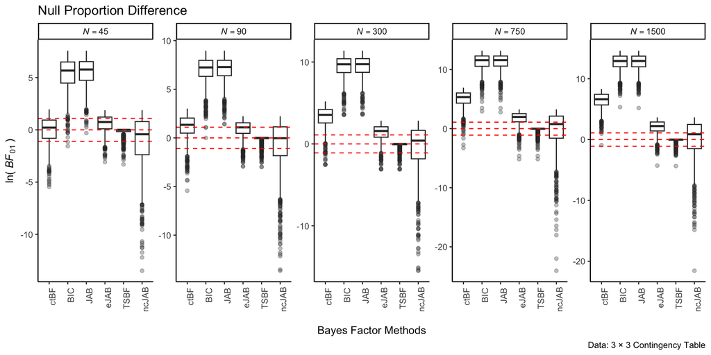

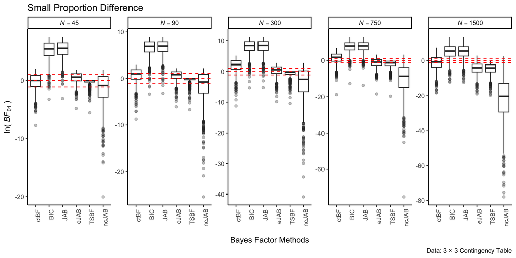

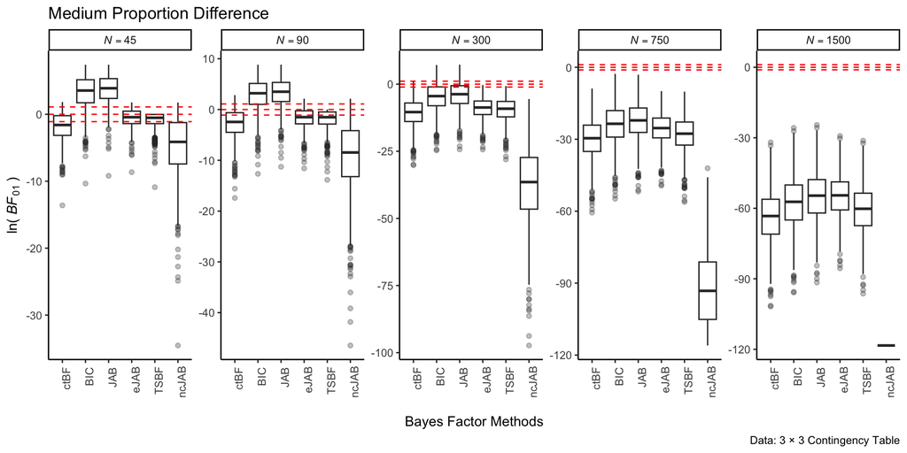

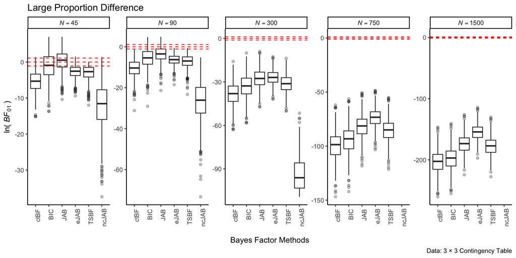

```r
df6_BF <- reshapeW2L4(reportBF, prob=F)

# boxplot of the BF₀₁
for (es in OMEGA) {
  sub <- subset(df6_BF, omega == es) # subset the long
  print(ggplot(sub, aes(x=method, y=log(value))) +
          geom_boxplot(alpha=0.3, na.rm=T) +
          geom_hline(yintercept=c(-log(3), 0, log(3)), linetype="dashed", color="red") +
          facet_wrap(.~n, scales="free_y", nrow=1,
                     labeller=label_bquote(cols=italic(N)==.(n))) +
          labs(x="\nBayes Factor Methods", y=expression("ln("~italic("BF")["01"]~")"),
               caption=paste0("Data: ", nR ," × ", nC, " Contingency Table")) +
          ggtitle(paste0(names(OMEGA[OMEGA==es]), " Proportion Difference")) +
          theme_classic() +
          theme(axis.text.x=element_text(angle=90, hjust=0.9)))
  cat("<br><br><br><br><br>")
}
```

When simulated under the alternative, some methods produce extremely small values supporting the null, which are rounded down to zero. This results in their log values being reported as negative infinity, and consequently, no boxes are shown in the figure.

scroll to top

### Boxplot (Percent Errors)

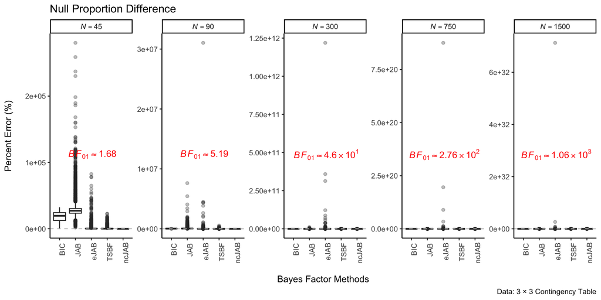

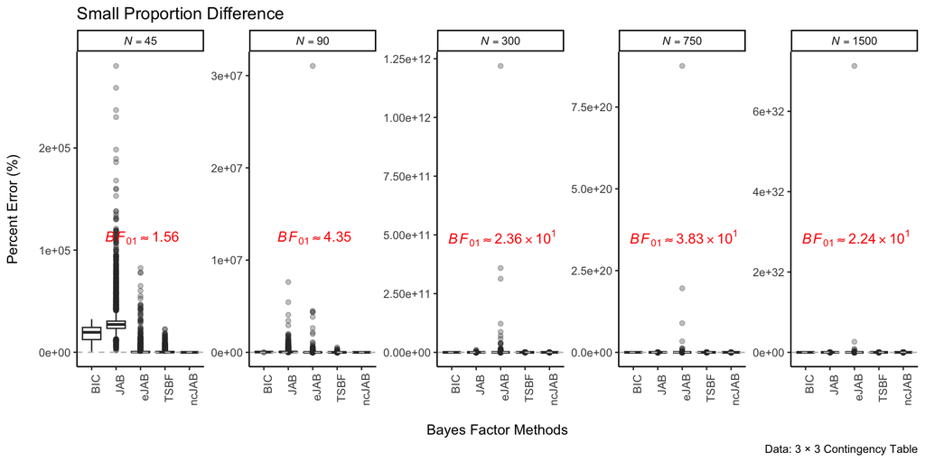

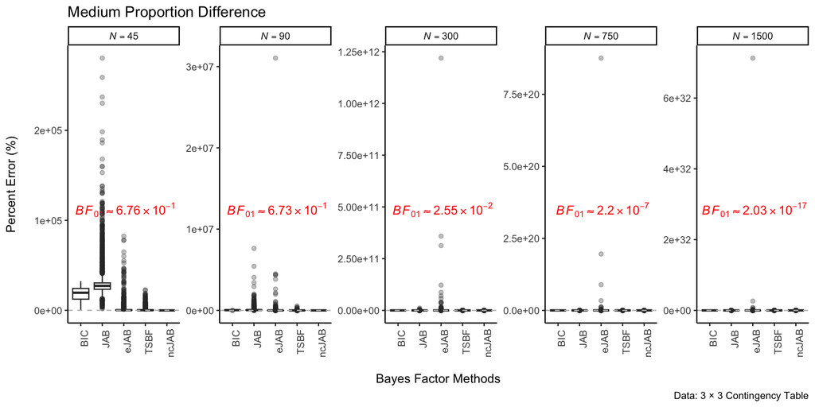

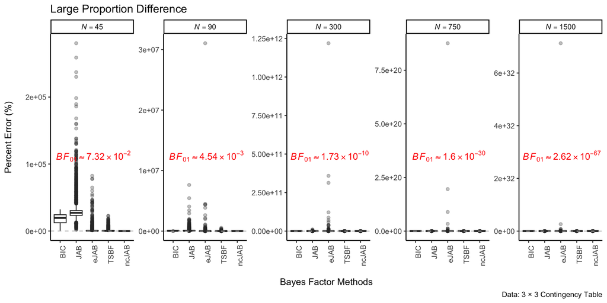

```r
# percent errors
df6 <- reshapeW2L4(reportERR, prob=F)

index <- 0

# boxplot of the percent errors
for (omega in OMEGA) {
  baseBF01 <- sapply(reportBF_avg[seq(1, by=length(OMEGA), length.out=length(nObs)) + index],
                     function(x) x[1]) # baseline is contingencyTableBF
  baseBF01_lab <- sapply(baseBF01, formatting) # scientific notation
  index <- index + 1

  sub <- subset(df6, method != "ctBF" & omega == omega) # subset the long
  anno <- data.frame("label"=baseBF01_lab, "n"=unique(sub$n),
                     "x"=3, "y"=.4 * aggregate(value~n, sub, FUN=max)$value) # for annotation use

  print(ggplot(sub, aes(x=method, y=value)) +
          geom_boxplot(alpha=0.3, na.rm=T) +
          geom_text(data=anno, aes(label=label, x=x, y=y), parse=T, col="red") +
          facet_wrap(.~n, scales="free_y", nrow=1,
                     labeller=label_bquote(cols=italic(N)==.(n))) +
          labs(x="\nBayes Factor Methods", y="Percent Error (%)\n",
               caption=paste0("Data: ", nR ," × ", nC, " Contingency Table")) +
          ggtitle(paste0(names(OMEGA[OMEGA==omega]), " Proportion Difference")) +
          geom_hline(yintercept=0, linetype="dashed", color="gray") + # reference line 0%
          theme_classic() +
          theme(axis.text.x=element_text(angle=90, hjust=0.9)))
  cat("<br><br><br><br><br><br><br>")
}
```

scroll to top

### Line Chart (Proportions of Agreement)

[interactive chart not shown]

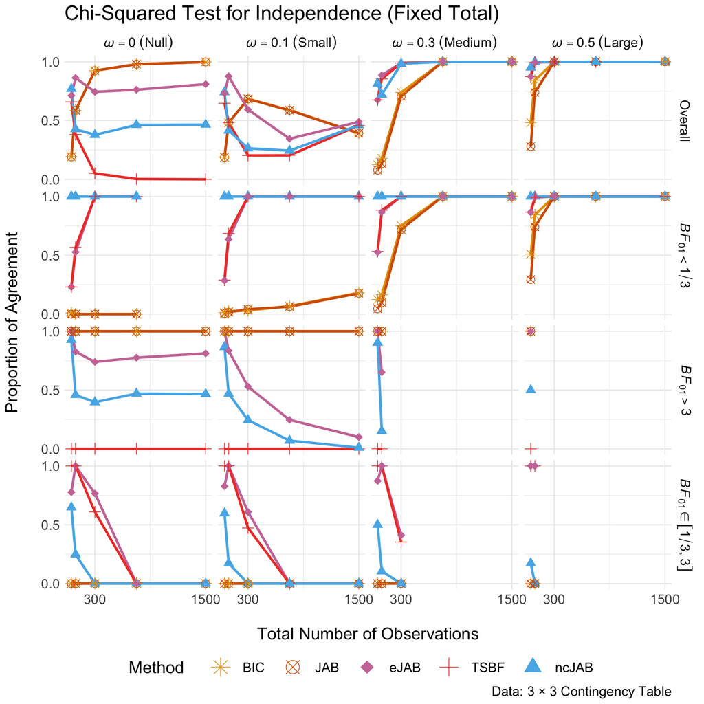

```r
# decisions
decis6 <- rbind(reshapeW2L4(reportRULE),
                reshapeW2L4(reportRULE_H1),
                reshapeW2L4(reportRULE_H0),
                reshapeW2L4(reportRULE_inc))
decis6$result <- factor(rep(c("Overall", "BF01 < 1/3", "BF01 > 3", "[1/3, 3]"),
                            each=length(levels(df6$method)) * length(nObs) * length(OMEGA)),
                        levels=c("Overall", "BF01 < 1/3", "BF01 > 3", "[1/3, 3]"))
decis6$omega <- paste0("ES = ", decis6$omega)
decis6 <- decis6[!is.na(decis6[,"prop"]),]
if (F) {
  # compute the pointwise confidence intervals using the normal approximation
  decis6$half.len <- qnorm(1-.05/2) *
    sqrt(decis6$value * (decis6$total - decis6$value) / decis6$total^3) # 95% CI width
  decis6$lwr <- max(0, decis6$value / decis6$total - decis6$half.len) # 95% CI lower bound
  decis6$upr <- min(1, decis6$value / decis6$total + decis6$half.len) # 95% CI upper bound
} else { # Jeffreys intervals
  decis6$lwr <- qbeta(.05/2, decis6$value, decis6$total - decis6$value + 1) # 95% CI lower bound
  decis6$upr <- qbeta(1-.05/2, decis6$value + 1, decis6$total - decis6$value) # 95% CI upper bound
  decis6$half.len <- (decis6$upr - decis6$lwr) / 2 # 95% CI width
}

# line chart of the proportions of agreement
ggplotly(ggplot(decis6, aes(n, prop, color=method, label=value)) +
           geom_line(linewidth=1.2, na.rm=T) + geom_point(size=2, na.rm=T) +
           geom_ribbon(aes(ymin=lwr, ymax=upr), alpha=.2) +
           scale_color_manual(values=c("black", "#E69F00", "#D55E00", "#CC79A7", "#EF4135", "#56B4E9"),
                              labels=c("ctBF", "BIC", "JAB", "eJAB", "TSBF", "ncJAB")) +
           facet_grid(result~omega) +
           labs(x="Total Number of Observations", y="Proportion of Agreement", color="Method") +
           scale_x_continuous(breaks=c(45, 300, 1500)) +
           scale_y_continuous(breaks=c(0, 0.5, 1)) + # min(decis6$prop, na.rm=T)
           theme_minimal()) # interactive plots
```

scroll to top

## 3B. Table $3\times3$ (`indepMulti`)

Visualization (Fixed Row Sums)

### Boxplot ($\ln\textit{BF}_{01}$)

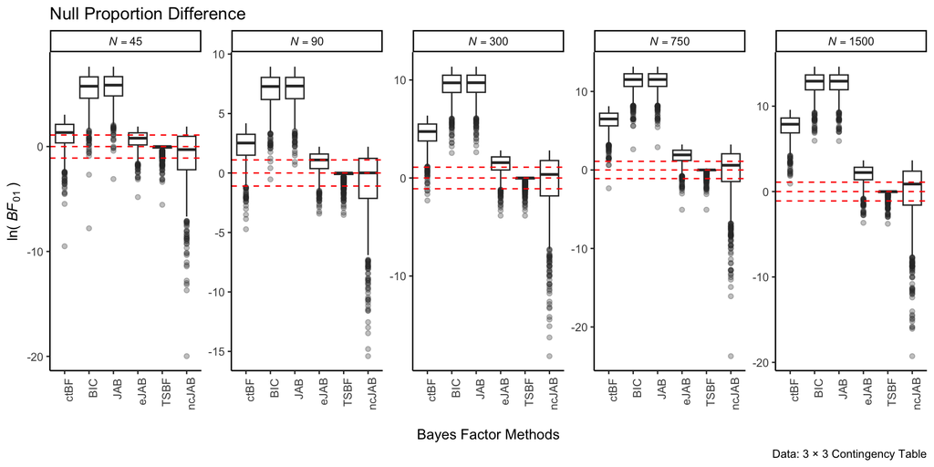

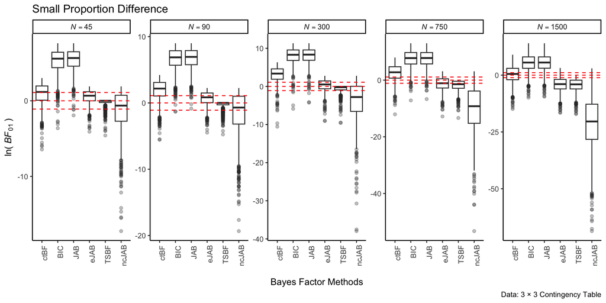

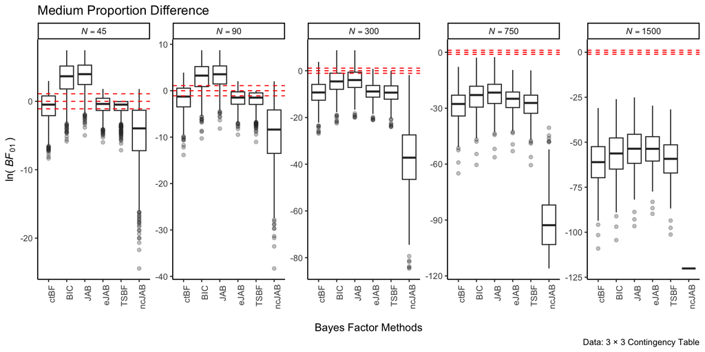

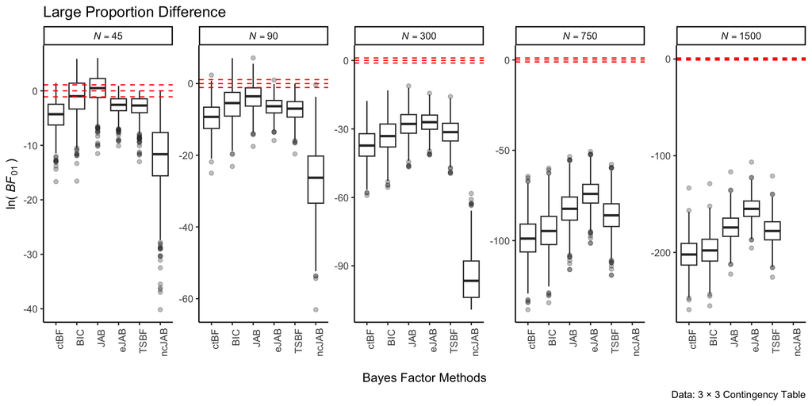

When simulated under the alternative, some methods produce extremely small values supporting the null, which are rounded down to zero. This results in their log values being reported as negative infinity, and consequently, no boxes are shown in the figure.

scroll to top

### Boxplot (Percent Errors)

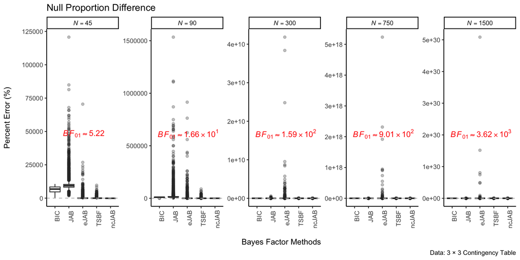

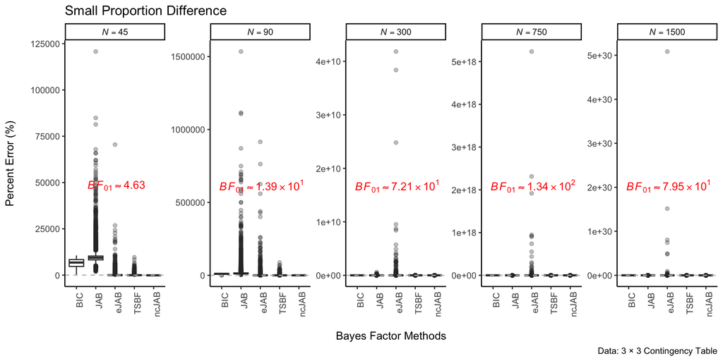

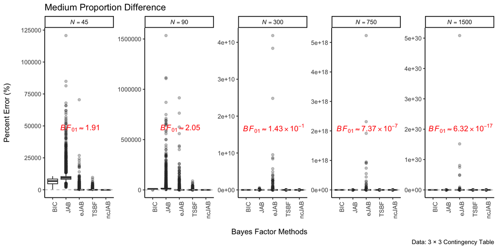

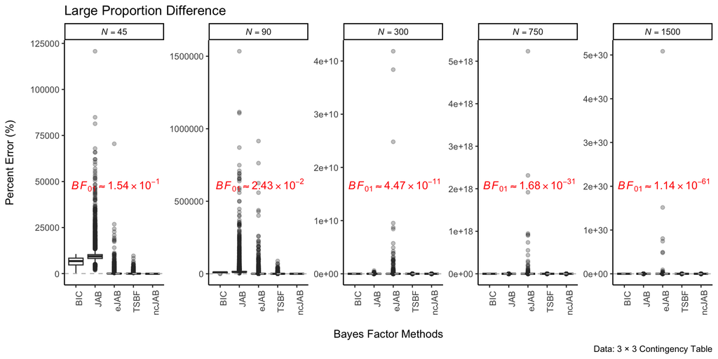

scroll to top

### Line Chart (Proportions of Agreement)

[interactive chart not shown]

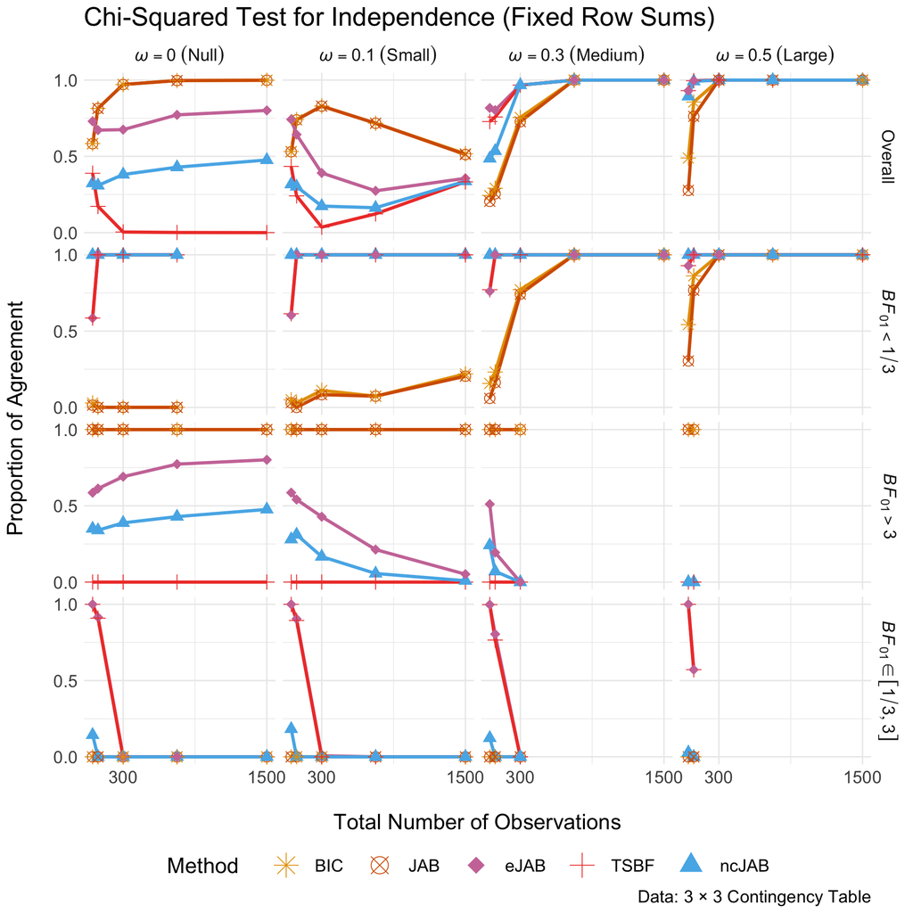

scroll to top

## 4A. Table $4\times5$ (`jointMulti`)

Visualization (Fixed Total)

### Boxplot ($\ln\textit{BF}_{01}$)

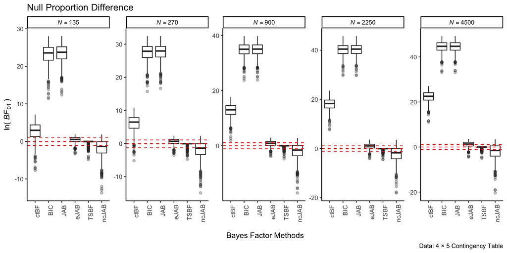

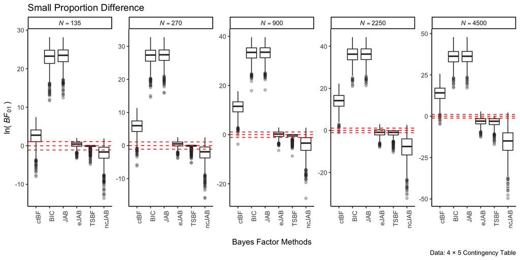

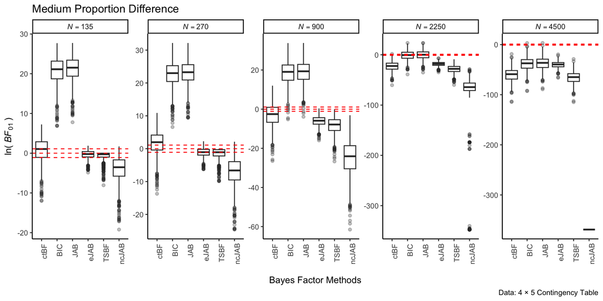

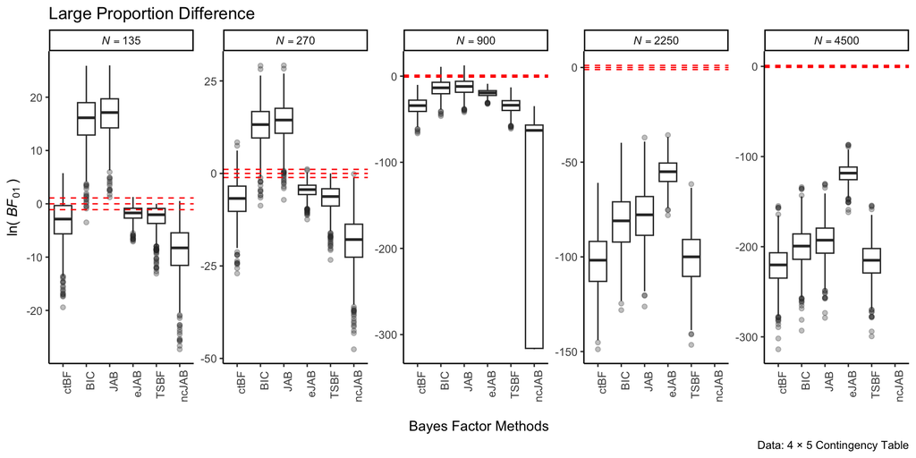

When simulated under the alternative, some methods produce extremely small values supporting the null, which are rounded down to zero. This results in their log values being reported as negative infinity, and consequently, no boxes are shown in the figure.

scroll to top

### Boxplot (Percent Errors)

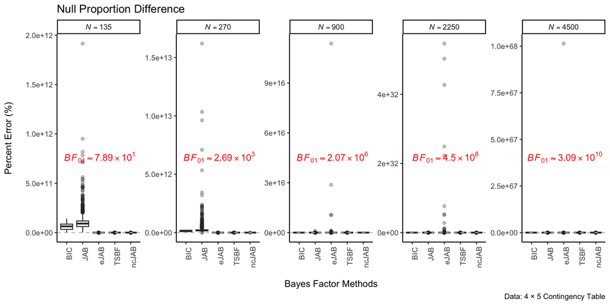

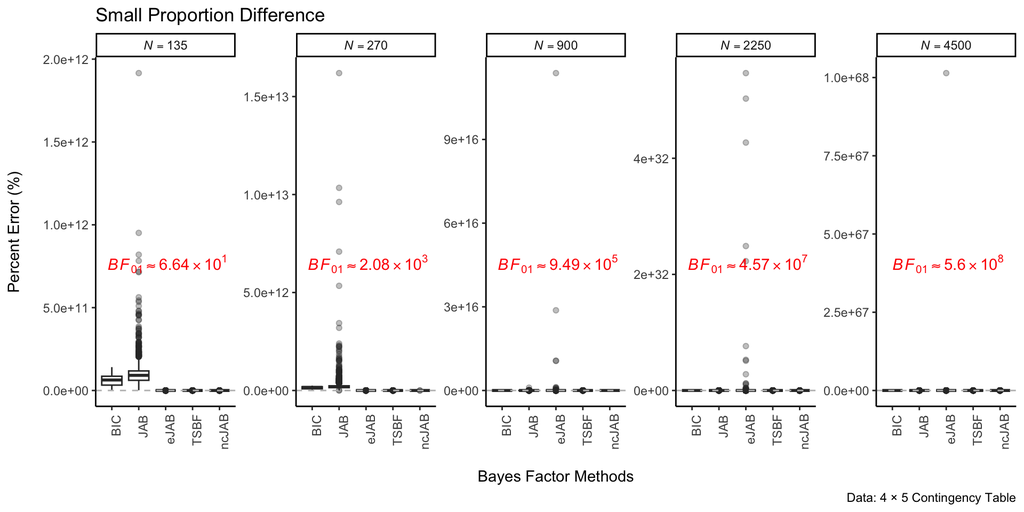

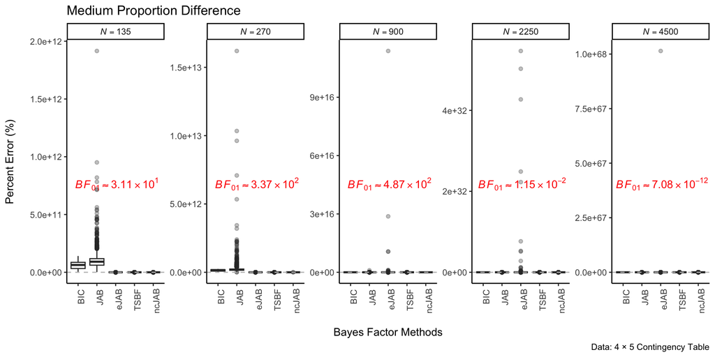

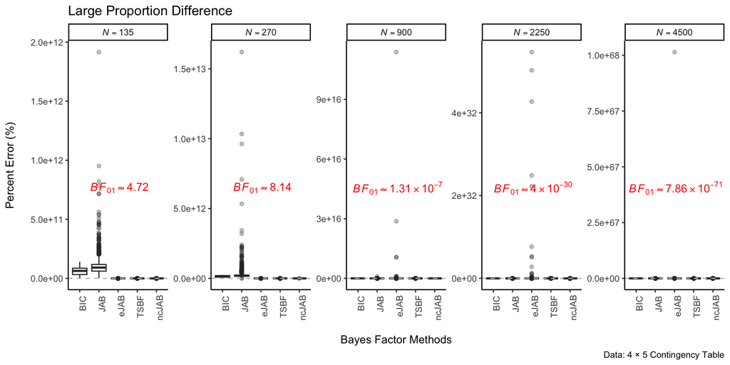

scroll to top

### Line Chart (Proportions of Agreement)

[interactive chart not shown]

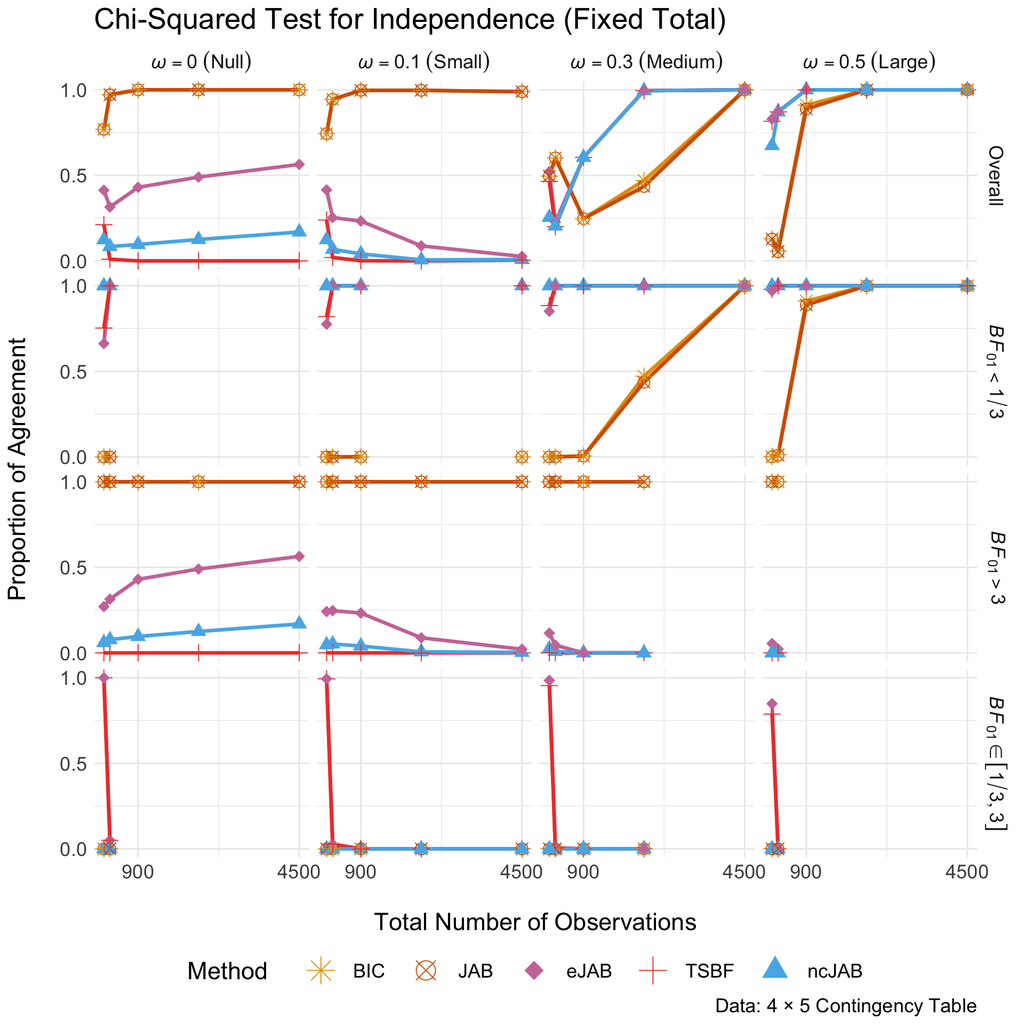

scroll to top